# induction

```python
from IPython.display import YouTubeVideo
```

Dynamic fields I: electromagnetic induction

Class notes for Physics for computer science and AI.

1. Motional electromotive force
2. Faraday's law
3. Lenz's law
4. Alternators
5. Self-inductance
6. Inductors
7. Mutual inductance
8. Eddy currents

**Recommended readings**

- Sears and Zemansky's University physics-Addison Wesley (credit: I will mostly follow this book, many figures in these slides taken from it)
  - Chapters 29,30

# 1. Motional electromotive force

A conductor **moving** in a magnetic field is able to induce an **electromotive force**.

**Slidewire generator**: Let's consider a metal rod with length $L$ placed across a U-shaped conductor closing a circuit, moving at a constant velocity $\vec v$. The circuit is inside a uniform magnetic field (directed into the circuit's plane). This induces an emf and a current along the circuit.

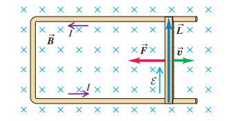

Free moving charges in the moving rod experience a magnetic force $\vec{{F}}=q \vec{v}_{rod} \times \vec{{B}}$. This force causes the positive (negative) free charges to move upwards (downwards), like an electric field of value $q E=q v_{rod} B$. The effective voltage between the endpoints of the rod must be

$$V_{a b}=\mathcal E=E L=v_{rod} B L$$

## 1.1. General expression

It is straightforward to generalize the previous result for an arbitrary circuit.For an element $d\vec l$, the contribution $d\mathcal E$ to the emf is the component of the magnetic force parallel to $d\vec l$. Adding up these contributions we have

| $$\mathcal{E}=\oint(\vec v \times \vec B) \cdot d \vec{l}$$ |
| --- |

# 2. Faraday's law

Faraday's law states that **a changing magnetic flux induces an electromotive force**. Namely, the induced emf in a closed loop equals the negative rate of change of magnetic flux through the loop.

| $$\mathcal{E}=-\frac{d \Phi_{B}}{d t}=-\frac{d}{dt}\int \vec{{B}} \cdot d \vec{A}=-\frac{d}{dt}\int B d A \cos \phi$$ |
| --- |

Generalization of a coil with N turns,

$$\mathcal{E}=-N \frac{d \Phi_{B}}{d t}$$

- Only a **dynamic flux** produces an emf, not a static flux.
- A dynamic flux is **not necessarily** produced by a dynamic magnetic field. The vector area $\vec A$ could also vary in time!
- Why the negative sign? It gives right the **direction** of the induced current.
- Experimental law that summarizes the experiments of Michael Faraday and Joseph Henry in the beginning of the XIX century.
- This law is at the hart of any electric generating station, which converts other forms of energy into electric energy(gravitational energy at hydroelectric plants, chemical energy in a coal-fired plant, or nuclear energy in a nuclear power plant)

```python
YouTubeVideo('Hh58afwzHfA')
```

[video not shown]

## 2.1 How to find the direction of the emf?

1. Fix direction of vector area $\vec A$.
2. In combination with the magnetic field, determine the sign of the magnetic flux (through the dot product $\vec{B} \cdot d \vec{A}$)
3. Determine the sign of the induced emf or current using Faraday's law: when the flux increases, the induced emf or current decreases and vice versa.
4. Finally, use the right-hand rule to determine the direction of the induced emf or current. For a positive emf, it is in thee same direction as your curled fingers, and negative otherwise.

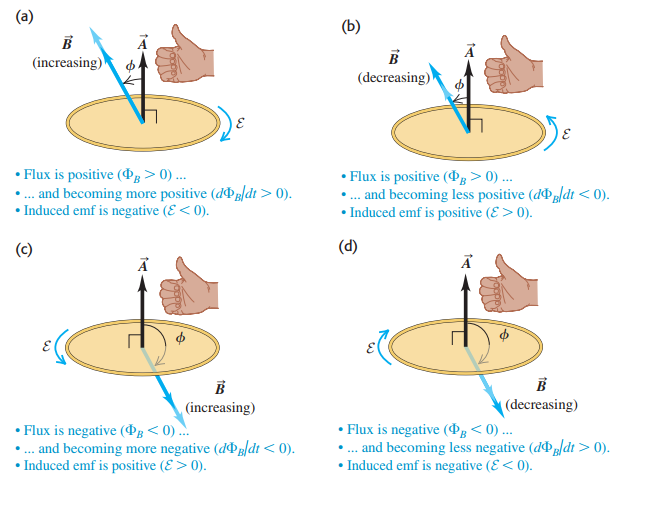

## 2.2 Induced electric field

We can understand the emf induced in a moving conductor based on Lorentz forces, but what drives the charges around the circuit when the conductor is still and there is only a changing magnetic flux?

Let us re-express Faraday's law using the definition of an emf

| $$\oint_{C} \vec{E} \cdot d \vec{l}=-\frac{d}{d t} \int_{S} \vec{B} \cdot \vec{n} d A$$ |
| --- |

There has to be **an induced electric field in the conductor caused by a changing magnetic flux**!

Remarks:

- Contrary to what we study for a static fields, this electric field does not fulfill $\oint_{C} \vec{E} \cdot d \vec{l}=0$, hence it is **not conservative** and the concept of potential is meaningless! Only when $\frac{d \Phi_{B}}{d t}=0$ we recover a conservative field $\vec E$. Nonetheless, **the definition $\vec F=q\vec E$ is always correct**.

### 2.2.1 Example: circular loop arround a solenoid

Let's consider a solenoid with $N/L$ being the number of turns per unit length, and a surrounding conducting loop with resistance $R$.

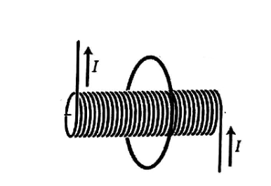

The magnetic field inside the solenoid is $$B=\mu_0\frac{N}{L}I(t)$$

According the Faraday's law, the induced emf in the surrounding loop is

$$\mathcal{E}=-\frac{d \Phi_{B}}{d t}=-\mu_{0} \frac{N}{L} A \frac{d I(t)}{d t}$$

(which induces a current $I'=\mathcal{E}/R$)

The symmetry of this configuration indicates that the induced electric field goes in circles around the solenoid. Therefore

$$\oint \vec{{E}} \cdot d \vec{{l}}=2 \pi r E=-\mu_{0} \frac{N}{L} A \frac{d I(t)}{d t}\implies \vec E=-\frac{\mu_{0}NA}{2\pi r L} \frac{d I(t)}{d t}\hat u_{\varphi}$$

# 3. Lenz's law

Lenz's law states: **the induced emf or current in a circuit opposes the change in magnetic flux**.

*Remarks*:

- It is a **qualitative law** that specifies the direction of induced current but not its module.
- It is an **alternative** (and more intuitive) way the direction of the emf compared **to Faraday's law**.
- It was formulated by the Russian scientist Emil Lenz (1804–1865) who independently from Faraday and Henry discovered it.
- Lenz's law may be seen as analogous to Newton's third law in classical mechanics.
- Lenz's law is a consequence of the **conservation of energy**.

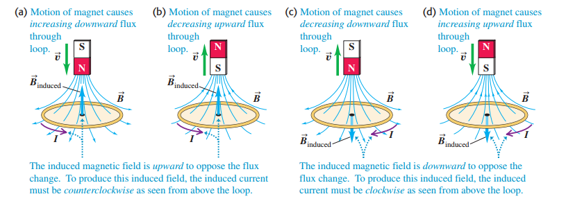

## 3.1 Slidewire generator revised

Applying Faraday's law to the slidewire generator we derive the same expression that we derived using the Lorentz force.

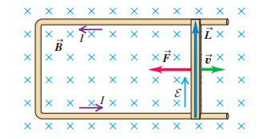

$$\mathcal{E}=-\frac{d \Phi_{B}}{d t}=-B \frac{d A}{d t}=-B \frac{L v d t}{d t}=-B L v$$

The minus sign indicates that the emf is directed counterclockwise around the loop.

The induced emf produces a current around the loop of magnitude $I=\mathcal E/R=BLv/R$. As a result, the rod experiences a magnetic force $\vec F=I\vec L\times \vec B$ opposed to the velocity (as an expression of Lenz's law). To keep a constant velocity, the applied force must compensate the magnetic force, hence

$$F=I L B=\frac{B L v}{R} L B=\frac{B^{2} L^{2} v}{R}$$

One can also check that the work done per unit time on the rod $P_{applied}=Fv$ compensates the power dissipated by the circuit $P_{dissipated}=I^2R$ (conservation of energy).

- The slidewire generator **transforms mechanical energy into electric energy**, conserving energy in the process.

The equations

$$\mathcal{E}=\oint(\vec v \times \vec B) \cdot d \vec{l} \label{motional}$$$$\mathcal{E}=-\frac{d \Phi_{B}}{d t}\label{faraday}$$

are actually expressions of Faraday's law. The former is more convenient formulation for moving conductors, while the latter is necessary for stationary conductors in changing magnetic fields.

# 4. Alternator

An alternator (alternating-current generator or **AC generator**) is a device that induces an **alternating emf** in a coil. The coil rotates with constant angular velocity inside a constant and uniform magnetic field.

Applying Faraday's law

$$\mathcal{E}=-\frac{d \Phi_{B}}{d t}=-\frac{d}{d t}(B A \cos \omega t)=\omega B A \sin \omega t$$

- The alternator converts **mechanical rotational energy into electric energy**.
- A commutator or a rectifier is needed to produce direct current (DC), exactly as in the DC motor.

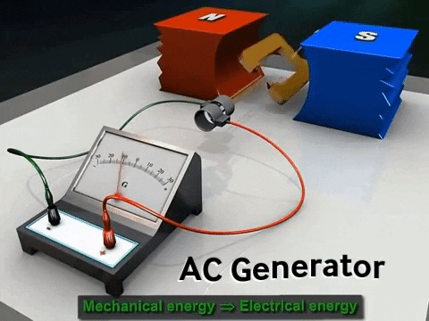

## 4.1 The Faraday disk dynamo (or homopolar generator)

Let's study the following configuration

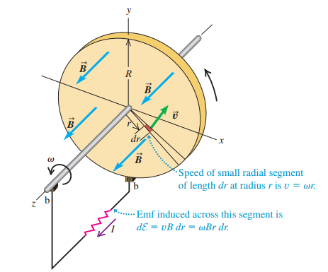

As $\vec v=\vec w\times \vec r$ (with $\vec w$ being the angular velocity) and $\vec B$ are perpendicular, and $d\vec l=rdr \hat r$, the expression of the motional electromotive force gives

$$d \mathcal{E}=(\vec{v} \times \vec{B}) \cdot d \vec{l}=\omega B r dr.$$

Thus,

$$\mathcal{E}=\int_{0}^{R} \omega B r d r=\frac{1}{2} \omega B R^{2}$$

Unlike the alternator, the Faraday disk dynamo is a direct-current generator (**DC generator**).

```python
YouTubeVideo('phrT2I_fu0g')
```

[video not shown]

# 5. Self-inductance

The magnetic flux through an isolated circuit (the flux produced by the circuit itself) depends on the geometry of the circuit and the current. Hence, for a stationary and rigid circuit the change in the flux is due to changes in current. We can then write

$$\frac{d \Phi}{d t}=\frac{d \Phi}{d I} \frac{d I}{d t}$$

We define the self-inductance (or simply inductance) $L$

| $$L=\frac{d \Phi}{d I}$$ |
| --- |

Faraday's law can then be expressed as

| $$\mathcal{E}=-L \frac{d I}{d t}$$ |
| --- |

*Properties*

- When the circuit lies in a linear magnetic medium (like vacuum), the flux linearly depends on the current, according to the Biot-Savart law. Therefore, the self-inductance is simply the proportionality constant between current and flux

| $$L=\frac{\Phi}{I}$$ |
| --- |

- For coil with N turns and current $i$ in each loop, $L=\frac{N\Phi}{i}$. As the flux in turn depends on $N$, the self-inductance is proportional to $N^2$.
- the SI unit of self-inductance is the henry (H) in honor of the American physicist Joseph Henry (1797–1878). $1 \mathrm{H}=1 \mathrm{Wb} / \mathrm{A}=1 \mathrm{V} \cdot \mathrm{s} / \mathrm{A}=1 \Omega \cdot \mathrm{s}=1 \mathrm{J} / \mathrm{A}^{2}$. Analogously to the farad, the henry is a rather large unit of mutual inductance. Typical values of mutual inductance lies in the range of millihenry ($mH$) or microhenry ($\mu H$).
- **The self-induced emf in a circuit opposes any change in the current in that circuit.**

## 5.1 Example: toroidal solenoid

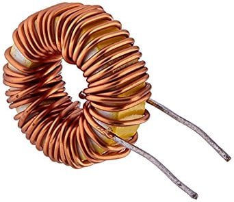

Applying Ampere's circuital law, it's straightforward to derive the self-inductance of a toroidal solenoid of radius $R$ and cross-sectional area $A$. We assume a ferromagnetic core of magnetic permeability $\mu$ $$L=\frac{N \Phi_{B}}{i}=\frac{\mu N^{2} A}{2 \pi R}$$

# 6. Inductors

An inductor is a circuit component designed to have a specific inductance. Although the electric field created by magnetic induction is nonconservative, we can still associate a voltage drop between its terminals

| $$V_{a b}=L \frac{d i}{d t}$$ |
| --- |

using the convention indicated in the figure,

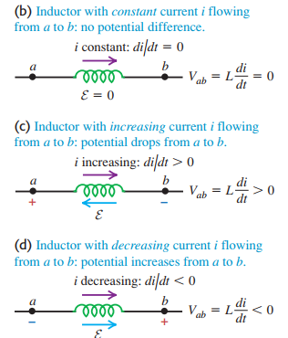

*Properties*

- They are normally built with **solenoids** or toroidal solenoids with **ferromagnetic core**. For these materials we use the corresponding magnetic permeability $\mu=\mu_r\mu_0$, which greatly amplifies the inductance.
- Unlike a resistor, **an inductor stores energy** in the induced magnetic field (analogously to a capacitor, which stores energy in the electric field)
- In a direct-current circuit, inductors are **used to keep a steady current despite any voltage fluctuations**.
- In an alternating-current circuit, inductors are used to filter current variations with high frequencies (**low-pass filters**).
- An inductor exhibits "inertia". When current decreases very rapidly in a circuit, the **back emf** increases dangerously, which may end up burning out some circuit component.

```python
YouTubeVideo('KSylo01n5FY')
```

[video not shown]

```python
# back emf
YouTubeVideo('kW2Nq6b-NJA')
```

[video not shown]

## 6.1 Magnetic field energy of an inductor

To establish a current in an inductor requires certain amount of energy, employed in creating the induced magnetic field. Let's assume an ideal inductor with zero resistance, then the energy supplied to the inductor during an infinitesimal time interval $dt$ is

$$d U=Pdt=V_{ab}idt=L i d i$$

.

Integrating we find the total energy

| $$U=L \int_{0}^{I} i d i=\frac{1}{2} L I^{2}$$ |
| --- |

Once the magnetic field is created, the inductor is charged. If the current decreases, the inductors becomes a source that supplies current to the circuit until it consumes its stored energy.

In general, one can show (beyond the scope of this course) that, for any type of inductor, the magnetic energy density $u=U/V$ (magnetic energy per unit volume) can be calculated as

| $$u=\frac{B^{2}}{2 \mu}$$ |
| --- |

Taking the toroidal solenoid for a demonstration,

$$ u=\frac{U}{V}=\frac{1/2LI^2}{2\pi r A}=\frac{1}{2} \mu \frac{N^{2} I^{2}}{(2 \pi r)^{2}}=\frac{B^{2}}{2 \mu} $$

# 7. Mutual inductance

So far we have considered isolated circuits. Let us now assume a collection of n circuits. The magnetic flux crossing the ith circuit is simply the sum of the contributions of all circuits (including itself).

$$\Phi_{i}=\Phi_{i 1}+\Phi_{i 2}+\cdots+\Phi_{i i}+\cdots+\Phi_{i n}=\sum_{j=1}^{n} \Phi_{i j}$$

where $\Phi_{i 1}$ symbolizes the flux crossing the ith circuit due to circuit 1 and so on. The induced emf is then

$$\mathcal{E}_{i}=-\frac{d \Phi_{i}}{d t}=-\left\{\frac{d \Phi_{i 1}}{d t}+\cdots+\frac{d \Phi_{i i}}{d t}+\cdots+\frac{d \Phi_{i n}}{d t}\right\}=-\sum_{j=1}^{n} \frac{d \Phi_{i j}}{d t}$$

If each of these circuits is stationary and rigid, the only changes in $\Phi_{ij}$ are due to the changes in the currents. Hence

$$\frac{d \Phi_{i j}}{d t}=\frac{d \Phi_{i j}}{d I_{j}} \frac{d I_{j}}{d t}$$

.

We define the mutual inductance $M_{ij}$

$$M_{i j}=\frac{d \Phi_{i j}}{d I_{j}}\:\:(i\neq j)$$

All in all, a changing current in a coil induces an emf in an adjacent coil, and the mutual inductance describes their coupling.

*Properties*:

- When the magnetic medium is **linear** (like vacuum), the mutual inductance is constant and current-independent, given by

| $$M_{ij}=\frac{\Phi_{i j}}{I_j}$$ |
| --- |

- Mutual inductance is symmetric $M_{ij}=M_{ji}$
- SI units is the henry (same as self-inductance)
- Be careful: a steady current in one coil does not induce any current in a neighboring coil.
- Mutual inductance may become a severe nuisance in complex circuits, as variations in current in one circuit induce **unwanted emfs** in neighboring circuits. A good multi-circuit design tries to minimize their mutual inductance.

*Applications*:

- A **transformer** is used in AC circuits to raise or lower voltages. The output voltage is determined by the mutual inductance.
- **Wireless charger**: for example, a electric toothbrush is charged thanks to a mutual inductance between the base, which contains a coil supplied with AC current from a wall socket, and a coil inside the toothbrush that is connected to a rechargeable battery.

## 7.1 Example: long solenoid surrounded by a coil

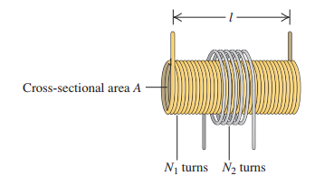

$$M=\frac{N_{2} \Phi_{B 2}}{i_{1}}=\frac{N_{2} B_{1} A}{i_{1}}=\frac{N_{2}}{i_{1}} \left(\frac{\mu_{0} N_{1} i_{1}}{l}\right) A=\frac{\mu_{0} A N_{1} N_{2}}{l}$$

# 8. Eddy currents (Foucault's currents)

So far we have assumed that currents are essentially confined in one-dimensional paths. Nonetheless, in many cases we find metallic pieces of electrical equipment moving in magnetic fields or located in changing magnetic fields. As a result, induced currents will circulate throughout the volume of the metal, with flow patterns resembling swirling eddies in a river.

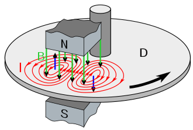

Eddy currents induce **drag forces** on moving objects, and also **waste heat**.

*Applications*:

- Heating: eddy currents are used to heat materials in completely sealed containers for processes in which it is essential to avoid the slightest contamination of the materials.
- Metal detectors: metal detectors used at security checkpoints operate by detecting eddy currents induced in metallic objects.
- Magnetic breaks: the moving conductor experiences a drag force from the magnet that opposes its motion, proportional to its velocity. The kinetic energy of the moving object is dissipated as heat generated by the current flowing through the electrical resistance of the conductor.

```python
# eddy currents opposes movement
YouTubeVideo('sENgdSF8ppA')
```

[video not shown]

```python
# eddy currents+resistance implies heating
YouTubeVideo('8i2OVqWo9s0')
```

[video not shown]

# Appendix

```python
# A solenoid engine
YouTubeVideo('MqG3yC58Maw')
```

[video not shown]

```python
# state of the art magnetic engines
YouTubeVideo('esUb7Zy5Oio')
```

[video not shown]

```python
# Non-intuitive effects of non-conservative electric fields
YouTubeVideo('eqjl-qRy71w')
```

[video not shown]